# Machine Learning Project

MLR

september 2016

## Background

Using devices such as Jawbone Up, Nike FuelBand, and Fitbit it is now possible to collect a large amount of data about personal activity relatively inexpensively. These type of devices are part of the quantified self movement – a group of enthusiasts who take measurements about themselves regularly to improve their health, to find patterns in their behavior, or because they are tech geeks. One thing that people regularly do is quantify how much of a particular activity they do, but they rarely quantify how well they do it. In this project, your goal will be to use data from accelerometers on the belt, forearm, arm, and dumbell of 6 participants. They were asked to perform barbell lifts correctly and incorrectly in 5 different ways.

## Preparing and investigating the data

```r
library(ggplot2); library(caret)
# Reading files
orgtrain <- read.csv("https://d396qusza40orc.cloudfront.net/predmachlearn/pml-training.csv")
orgtest <- read.csv("https://d396qusza40orc.cloudfront.net/predmachlearn/pml-testing.csv")

# creating new dataframe with only the accelerometer data
mtottrain <- orgtrain[,c(40,41,42,    #belt
                    63,64,65,    #arm
                    116,117,118, #dumbbell
                    154,155,156, #forearm
                    160)]        #classe

# Investigating the dataset
head(mtottrain)
```

```
##   accel_belt_x accel_belt_y accel_belt_z accel_arm_x accel_arm_y
## 1          -21            4           22        -288         109
## 2          -22            4           22        -290         110
## 3          -20            5           23        -289         110
## 4          -22            3           21        -289         111
## 5          -21            2           24        -289         111
## 6          -21            4           21        -289         111
##   accel_arm_z accel_dumbbell_x accel_dumbbell_y accel_dumbbell_z
## 1        -123             -234               47             -271
## 2        -125             -233               47             -269
## 3        -126             -232               46             -270
## 4        -123             -232               48             -269
## 5        -123             -233               48             -270
## 6        -122             -234               48             -269
##   accel_forearm_x accel_forearm_y accel_forearm_z classe
## 1             192             203            -215      A
## 2             192             203            -216      A
## 3             196             204            -213      A
## 4             189             206            -214      A
## 5             189             206            -214      A
## 6             193             203            -215      A
```

```r
str(mtottrain)
```

```
## 'data.frame':    19622 obs. of  13 variables:
##  $ accel_belt_x    : int  -21 -22 -20 -22 -21 -21 -22 -22 -20 -21 ...
##  $ accel_belt_y    : int  4 4 5 3 2 4 3 4 2 4 ...
##  $ accel_belt_z    : int  22 22 23 21 24 21 21 21 24 22 ...
##  $ accel_arm_x     : int  -288 -290 -289 -289 -289 -289 -289 -289 -288 -288 ...
##  $ accel_arm_y     : int  109 110 110 111 111 111 111 111 109 110 ...
##  $ accel_arm_z     : int  -123 -125 -126 -123 -123 -122 -125 -124 -122 -124 ...
##  $ accel_dumbbell_x: int  -234 -233 -232 -232 -233 -234 -232 -234 -232 -235 ...
##  $ accel_dumbbell_y: int  47 47 46 48 48 48 47 46 47 48 ...
##  $ accel_dumbbell_z: int  -271 -269 -270 -269 -270 -269 -270 -272 -269 -270 ...
##  $ accel_forearm_x : int  192 192 196 189 189 193 195 193 193 190 ...
##  $ accel_forearm_y : int  203 203 204 206 206 203 205 205 204 205 ...
##  $ accel_forearm_z : int  -215 -216 -213 -214 -214 -215 -215 -213 -214 -215 ...
##  $ classe          : Factor w/ 5 levels "A","B","C","D",..: 1 1 1 1 1 1 1 1 1 1 ...
```

```r
dim(mtottrain)
```

```
## [1] 19622    13
```

```r
summary(mtottrain)
```

```
##   accel_belt_x       accel_belt_y     accel_belt_z      accel_arm_x
##  Min.   :-120.000   Min.   :-69.00   Min.   :-275.00   Min.   :-404.00
##  1st Qu.: -21.000   1st Qu.:  3.00   1st Qu.:-162.00   1st Qu.:-242.00
##  Median : -15.000   Median : 35.00   Median :-152.00   Median : -44.00
##  Mean   :  -5.595   Mean   : 30.15   Mean   : -72.59   Mean   : -60.24
##  3rd Qu.:  -5.000   3rd Qu.: 61.00   3rd Qu.:  27.00   3rd Qu.:  84.00
##  Max.   :  85.000   Max.   :164.00   Max.   : 105.00   Max.   : 437.00
##   accel_arm_y      accel_arm_z      accel_dumbbell_x  accel_dumbbell_y
##  Min.   :-318.0   Min.   :-636.00   Min.   :-419.00   Min.   :-189.00
##  1st Qu.: -54.0   1st Qu.:-143.00   1st Qu.: -50.00   1st Qu.:  -8.00
##  Median :  14.0   Median : -47.00   Median :  -8.00   Median :  41.50
##  Mean   :  32.6   Mean   : -71.25   Mean   : -28.62   Mean   :  52.63
##  3rd Qu.: 139.0   3rd Qu.:  23.00   3rd Qu.:  11.00   3rd Qu.: 111.00
##  Max.   : 308.0   Max.   : 292.00   Max.   : 235.00   Max.   : 315.00
##  accel_dumbbell_z  accel_forearm_x   accel_forearm_y  accel_forearm_z
##  Min.   :-334.00   Min.   :-498.00   Min.   :-632.0   Min.   :-446.00
##  1st Qu.:-142.00   1st Qu.:-178.00   1st Qu.:  57.0   1st Qu.:-182.00
##  Median :  -1.00   Median : -57.00   Median : 201.0   Median : -39.00
##  Mean   : -38.32   Mean   : -61.65   Mean   : 163.7   Mean   : -55.29
##  3rd Qu.:  38.00   3rd Qu.:  76.00   3rd Qu.: 312.0   3rd Qu.:  26.00
##  Max.   : 318.00   Max.   : 477.00   Max.   : 923.0   Max.   : 291.00
##  classe
##  A:5580
##  B:3797
##  C:3422
##  D:3216
##  E:3607
##
```

```r
summary(is.na(mtottrain))
```

```
##  accel_belt_x    accel_belt_y    accel_belt_z    accel_arm_x
##  Mode :logical   Mode :logical   Mode :logical   Mode :logical
##  FALSE:19622     FALSE:19622     FALSE:19622     FALSE:19622
##  NA's :0         NA's :0         NA's :0         NA's :0
##  accel_arm_y     accel_arm_z     accel_dumbbell_x accel_dumbbell_y
##  Mode :logical   Mode :logical   Mode :logical    Mode :logical
##  FALSE:19622     FALSE:19622     FALSE:19622      FALSE:19622
##  NA's :0         NA's :0         NA's :0          NA's :0
##  accel_dumbbell_z accel_forearm_x accel_forearm_y accel_forearm_z
##  Mode :logical    Mode :logical   Mode :logical   Mode :logical
##  FALSE:19622      FALSE:19622     FALSE:19622     FALSE:19622
##  NA's :0          NA's :0         NA's :0         NA's :0
##    classe
##  Mode :logical
##  FALSE:19622
##  NA's :0
```

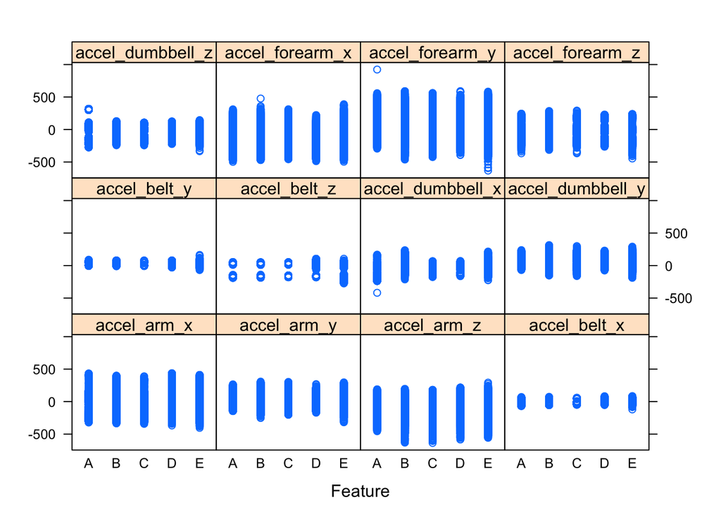

```r
# Plotting
featurePlot(x=mtottrain[,-c(13)],y=mtottrain$classe,plot="strip")
```

## Preparatin for cross validation

Accuracy on a training set is often optimistic. To be able to do a better estimate, I have chosen to split the original training set to a separate training and testing set. 70% of the data will be in this new training set and the rest in the testing set.

Estimating the test set accuray with the training set will hopefullt improve the accuarcy of the original testing set.

[output not shown]

[output not shown]

## Fitting different models to see which one gives the best accuracy.

I have chosen 3 of the methods which are used for categorization: - Gradiant Boosting - Random Foreset - Support Vector Machines

### Training result of Gradient Boosting model

```r
print (modfit1)
```

```
## Stochastic Gradient Boosting
##
## 13737 samples
##    12 predictor
##     5 classes: 'A', 'B', 'C', 'D', 'E'
##
## No pre-processing
## Resampling: Bootstrapped (25 reps)
## Summary of sample sizes: 13737, 13737, 13737, 13737, 13737, 13737, ...
## Resampling results across tuning parameters:
##
##   interaction.depth  n.trees  Accuracy   Kappa
##   1                   50      0.5397196  0.4077422
##   1                  100      0.5874844  0.4715076
##   1                  150      0.6188389  0.5126690
##   2                   50      0.6500496  0.5525172
##   2                  100      0.7207124  0.6442147
##   2                  150      0.7564628  0.6905074
##   3                   50      0.7170325  0.6394259
##   3                  100      0.7789871  0.7192493
##   3                  150      0.8088026  0.7574788
##
## Tuning parameter 'shrinkage' was held constant at a value of 0.1
##
## Tuning parameter 'n.minobsinnode' was held constant at a value of 10
## Accuracy was used to select the optimal model using  the largest value.
## The final values used for the model were n.trees = 150,
##  interaction.depth = 3, shrinkage = 0.1 and n.minobsinnode = 10.
```

### Training result of Random Forest model

```r
print (modfit2)
```

```
## Random Forest
##
## 13737 samples
##    12 predictor
##     5 classes: 'A', 'B', 'C', 'D', 'E'
##
## No pre-processing
## Resampling: Bootstrapped (25 reps)
## Summary of sample sizes: 13737, 13737, 13737, 13737, 13737, 13737, ...
## Resampling results across tuning parameters:
##
##   mtry  Accuracy   Kappa
##    2    0.9317247  0.9135446
##    7    0.9216902  0.9008387
##   12    0.9047562  0.8793967
##
## Accuracy was used to select the optimal model using  the largest value.
## The final value used for the model was mtry = 2.
```

```r
pred1 <- predict(modfit1,mtest)
pred2 <- predict(modfit2,mtest)
pred3 <- predict(modfit3,mtest)

confusionMatrix(pred1,mtest$classe)
```

```
## Confusion Matrix and Statistics
##
##           Reference
## Prediction    A    B    C    D    E
##          A 1486  145   95   87   14
##          B   37  836   54   14   70
##          C   62   88  846   68   53
##          D   82   40   24  771   40
##          E    7   30    7   24  905
##
## Overall Statistics
##
##                Accuracy : 0.8231
##                  95% CI : (0.8131, 0.8328)
##     No Information Rate : 0.2845
##     P-Value [Acc > NIR] : < 2.2e-16
##
##                   Kappa : 0.7756
##  Mcnemar's Test P-Value : < 2.2e-16
##
## Statistics by Class:
##
##                      Class: A Class: B Class: C Class: D Class: E
## Sensitivity            0.8877   0.7340   0.8246   0.7998   0.8364
## Specificity            0.9190   0.9631   0.9442   0.9622   0.9858
## Pos Pred Value         0.8134   0.8269   0.7574   0.8056   0.9301
## Neg Pred Value         0.9537   0.9378   0.9622   0.9608   0.9640
## Prevalence             0.2845   0.1935   0.1743   0.1638   0.1839
## Detection Rate         0.2525   0.1421   0.1438   0.1310   0.1538
## Detection Prevalence   0.3105   0.1718   0.1898   0.1626   0.1653
## Balanced Accuracy      0.9034   0.8486   0.8844   0.8810   0.9111
```

```r
confusionMatrix(pred2,mtest$classe)
```

```
## Confusion Matrix and Statistics
##
##           Reference
## Prediction    A    B    C    D    E
##          A 1618   51   22   18    1
##          B   12 1046   27    5   16
##          C   26   28  966   49   15
##          D   15   10   10  887    5
##          E    3    4    1    5 1045
##
## Overall Statistics
##
##                Accuracy : 0.9451
##                  95% CI : (0.939, 0.9508)
##     No Information Rate : 0.2845
##     P-Value [Acc > NIR] : < 2.2e-16
##
##                   Kappa : 0.9305
##  Mcnemar's Test P-Value : 1.353e-11
##
## Statistics by Class:
##
##                      Class: A Class: B Class: C Class: D Class: E
## Sensitivity            0.9665   0.9183   0.9415   0.9201   0.9658
## Specificity            0.9782   0.9874   0.9757   0.9919   0.9973
## Pos Pred Value         0.9462   0.9458   0.8911   0.9569   0.9877
## Neg Pred Value         0.9866   0.9805   0.9875   0.9845   0.9923
## Prevalence             0.2845   0.1935   0.1743   0.1638   0.1839
## Detection Rate         0.2749   0.1777   0.1641   0.1507   0.1776
## Detection Prevalence   0.2906   0.1879   0.1842   0.1575   0.1798
## Balanced Accuracy      0.9723   0.9529   0.9586   0.9560   0.9815
```

```r
confusionMatrix(pred3,mtest$classe)
```

```
## Confusion Matrix and Statistics
##
##           Reference
## Prediction    A    B    C    D    E
##          A 1446  147  108  126   25
##          B   44  817   69   15   71
##          C  104   98  812   99   73
##          D   63   25   21  708   54
##          E   17   52   16   16  859
##
## Overall Statistics
##
##                Accuracy : 0.7888
##                  95% CI : (0.7781, 0.7992)
##     No Information Rate : 0.2845
##     P-Value [Acc > NIR] : < 2.2e-16
##
##                   Kappa : 0.7319
##  Mcnemar's Test P-Value : < 2.2e-16
##
## Statistics by Class:
##
##                      Class: A Class: B Class: C Class: D Class: E
## Sensitivity            0.8638   0.7173   0.7914   0.7344   0.7939
## Specificity            0.9036   0.9581   0.9230   0.9669   0.9790
## Pos Pred Value         0.7808   0.8041   0.6847   0.8129   0.8948
## Neg Pred Value         0.9435   0.9339   0.9545   0.9489   0.9547
## Prevalence             0.2845   0.1935   0.1743   0.1638   0.1839
## Detection Rate         0.2457   0.1388   0.1380   0.1203   0.1460
## Detection Prevalence   0.3147   0.1726   0.2015   0.1480   0.1631
## Balanced Accuracy      0.8837   0.8377   0.8572   0.8507   0.8864
```

### Making predictions for the original testing set

```r
# creating new dataframe with only the accelerometer data
mtottest <- orgtest[,c(40,41,42,    #belt
                    63,64,65,    #arm
                    116,117,118, #dumbbell
                    154,155,156)] #forearm

pred_final <- predict(modfit2,mtottest)
```

## Expected out of sample error

```r
table(pred2,mtest$classe)
```

```
##
## pred2    A    B    C    D    E
##     A 1618   51   22   18    1
##     B   12 1046   27    5   16
##     C   26   28  966   49   15
##     D   15   10   10  887    5
##     E    3    4    1    5 1045
```

```r
sum(mtest$classe !=pred2)
```

```
## [1] 323
```

```r
sum(mtest$classe !=pred2) / length(mtest$classe)
```

```
## [1] 0.0548853
```